# lab8

Yuchen Song_201830360498 - Xuewen Wang_201830120252

2021/11/10

## The survey

### Ex1

These percentages are population parameters.

### Ex2

We must assume that the sampling method(sample collected) is random, normal and independent. Also, the sample should include as more countries and races as possible.  
Yes, it is reasonable. As long as we use proper approach.

### Data Loading

```r
load(url("http://www.openintro.org/stat/data/atheism.RData"))
```

### Ex3

There are 57 rows and 5 columns in Table 6.  
Each row represent the data of a country.  
The atheism in every row refers to the 4th column, which represents the percentage that atheist in population.

### Ex4

```r
us12 = subset(atheism, nationality == "United States" & year == "2012")
cal = table(us12$response)
cal["atheist"]/(cal["atheist"]+cal["non-atheist"])
```

```
##   atheist
## 0.0499002
```

Yes, the calculated response ratio agree with the percentage in Table 6.

## Inference on proportions

### Ex5

Conditions:  
1.The sample observations are randomly chosen from the population, and each response are independent from each other.  
2.Population size is large enough so that the SRS (without replace) doesn’t affect the population distribution.  
3.The Binomial distribution has to met (np>10 and n(1-p)>10) to be approximately Normal.

Yes, all the conditions can be met.

### Ex6

```r
rf12 = subset(atheism, nationality == "Russian Federation" & year == "2012")
inference(rf12$response, est = "proportion", type = "ci", method = "theoretical", success = "atheist")
```

```
## Single proportion -- success: atheist
## Summary statistics:
```

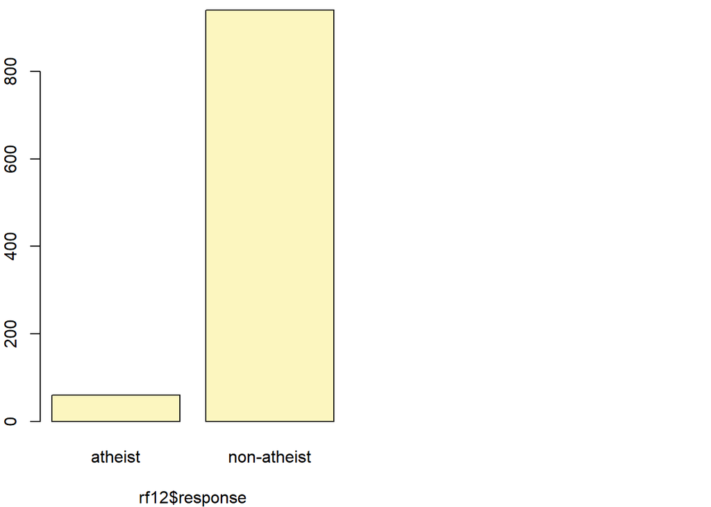

```
## p_hat = 0.06 ;  n = 1000
## Check conditions: number of successes = 60 ; number of failures = 940
## Standard error = 0.0075
## 95 % Confidence interval = ( 0.0453 , 0.0747 )
```

```r
bh12 = subset(atheism, nationality == "Bosnia and Herzegovina" & year == "2012")
inference(bh12$response, est = "proportion", type = "ci", method = "theoretical", success = "atheist")
```

```
## Single proportion -- success: atheist
## Summary statistics:
```

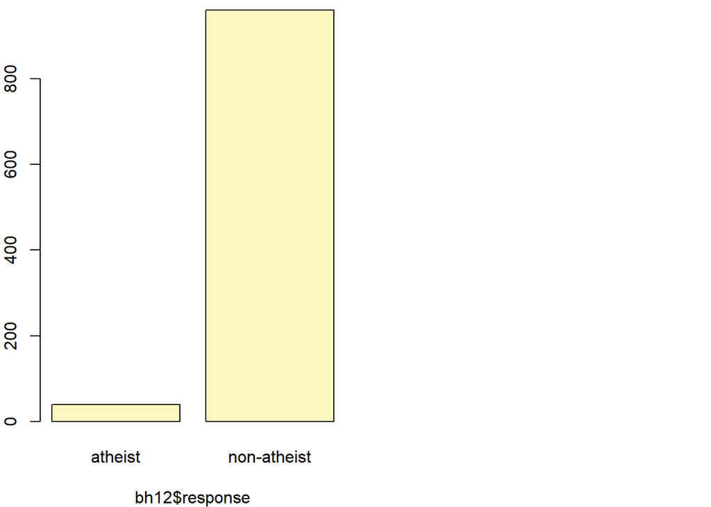

```
## p_hat = 0.04 ;  n = 1000
## Check conditions: number of successes = 40 ; number of failures = 960
## Standard error = 0.0062
## 95 % Confidence interval = ( 0.0279 , 0.0521 )
```

We choose Russian Federation and Bosnia and Herzegovina, data of both countries can meet with the condition.  
$M_{Russian\ Federation} = 0.0147, and\ M_{Bosnia\ and\ Herzegovina} = 0.0121$

## Success-failure condition

### Ex7

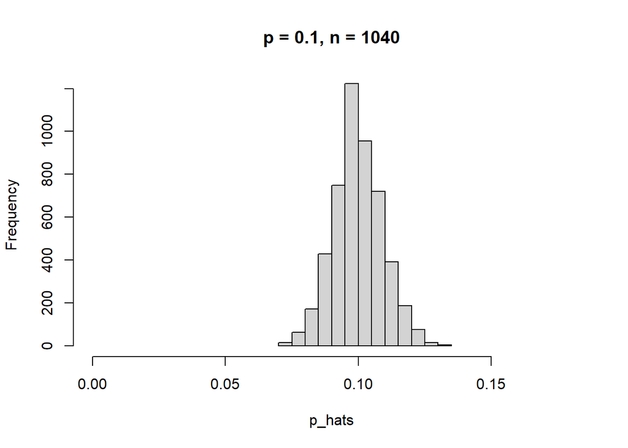

```r
set.seed(1147)
p = 0.1
n = 1040
p_hats = rep(0, 5000)

for(i in 1:5000){
  samp = sample(c("atheist", "non_atheist"), n, replace = TRUE, prob = c(p, 1-p))
  p_hats[i] = sum(samp == "atheist")/n
}

hist(p_hats, main = "p = 0.1, n = 1040", xlim = c(0, 0.18))
```

```r
summary(p_hats)
```

```
##    Min. 1st Qu.  Median    Mean 3rd Qu.    Max.
## 0.07019 0.09327 0.10000 0.09996 0.10577 0.13365
```

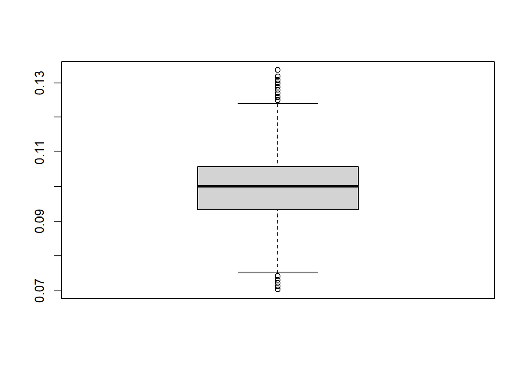

```r
boxplot(p_hats)
```

This sample distribution follows a Normal distribution(bell shaped), with center at 0.1, and spreads from 0.07019 to 0.13365.

### Ex8

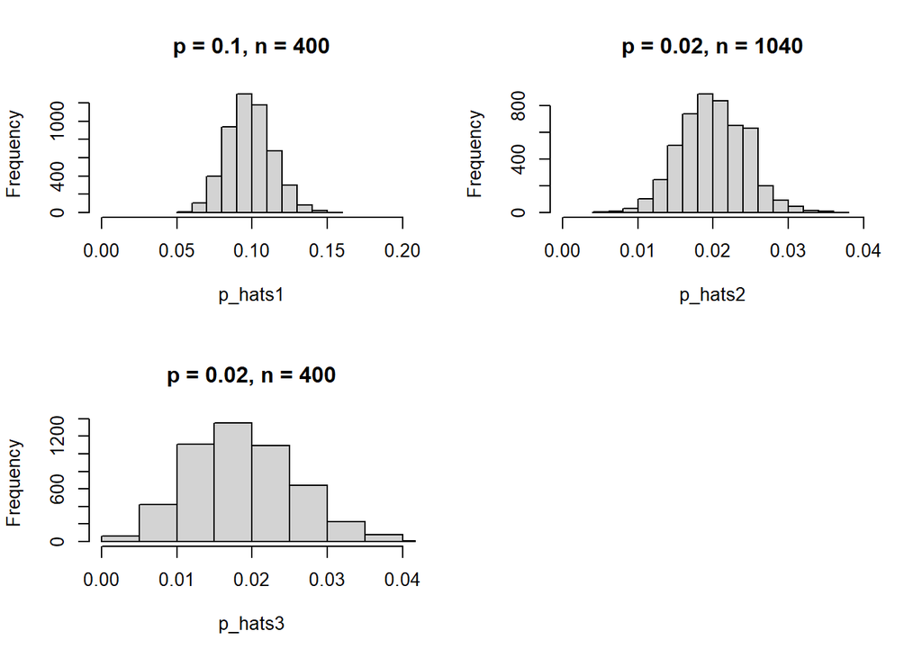

```r
set.seed(1152)
p1 = 0.1
p2 = 0.02
p3 = 0.02
n1 = 400
n2 = 1040
n3 =400
p_hats1 = rep(0, 5000)
p_hats2 = rep(0, 5000)
p_hats3 = rep(0, 5000)

for(i in 1:5000){
  samp1 = sample(c("atheist", "non_atheist"), n1, replace = TRUE, prob = c(p1, 1-p1))
  p_hats1[i] = sum(samp1 == "atheist")/n1

  samp2 = sample(c("atheist", "non_atheist"), n2, replace = TRUE, prob = c(p2, 1-p2))
  p_hats2[i] = sum(samp2 == "atheist")/n2

  samp3 = sample(c("atheist", "non_atheist"), n3, replace = TRUE, prob = c(p3, 1-p3))
  p_hats3[i] = sum(samp3 == "atheist")/n3
}

par(mfrow = c(2, 2))
hist(p_hats1, main = "p = 0.1, n = 400", xlim = c(0, 0.2))
hist(p_hats2, main = "p = 0.02, n = 1040", xlim = c(0, 0.04))
hist(p_hats3, main = "p = 0.02, n = 400", xlim = c(0, 0.04))
```

All three sample distributions are approximately Normal, centering at respective p.  
The formula is $\hat{p} \sim N(\mu_{\hat{p}}=p, \sigma_{\hat{p}}=\sqrt{\frac{p(1-p)}{n}})$  
So n does not affect the center of distribution, but influence the spread(i.e., with n gets larger, the spread shrinks, making the distribution more Normal).  
For p, p is the center of the distribution, and when p approximates 0.5, the spread get larger, making the distribution more like Normal.

### Ex9

```r
spain = subset(atheism, nationality == "Spain")
inference(y = spain$response, x = as.factor(spain$year), est = "proportion",type = "ht",null = 0, alternative = "twosided", method = "theoretical", success = "atheist")
```

```
## Response variable: categorical, Explanatory variable: categorical
## Two categorical variables
## Difference between two proportions -- success: atheist
## Summary statistics:
##              x
## y             2005 2012  Sum
##   atheist      115  103  218
##   non-atheist 1031 1042 2073
##   Sum         1146 1145 2291
```

```
## Observed difference between proportions (2005-2012) = 0.0104
##
## H0: p_2005 - p_2012 = 0
## HA: p_2005 - p_2012 != 0
## Pooled proportion = 0.0952
## Check conditions:
##    2005 : number of expected successes = 109 ; number of expected failures = 1037
##    2012 : number of expected successes = 109 ; number of expected failures = 1036
## Standard error = 0.012
## Test statistic: Z =  0.848
## p-value =  0.3966
```

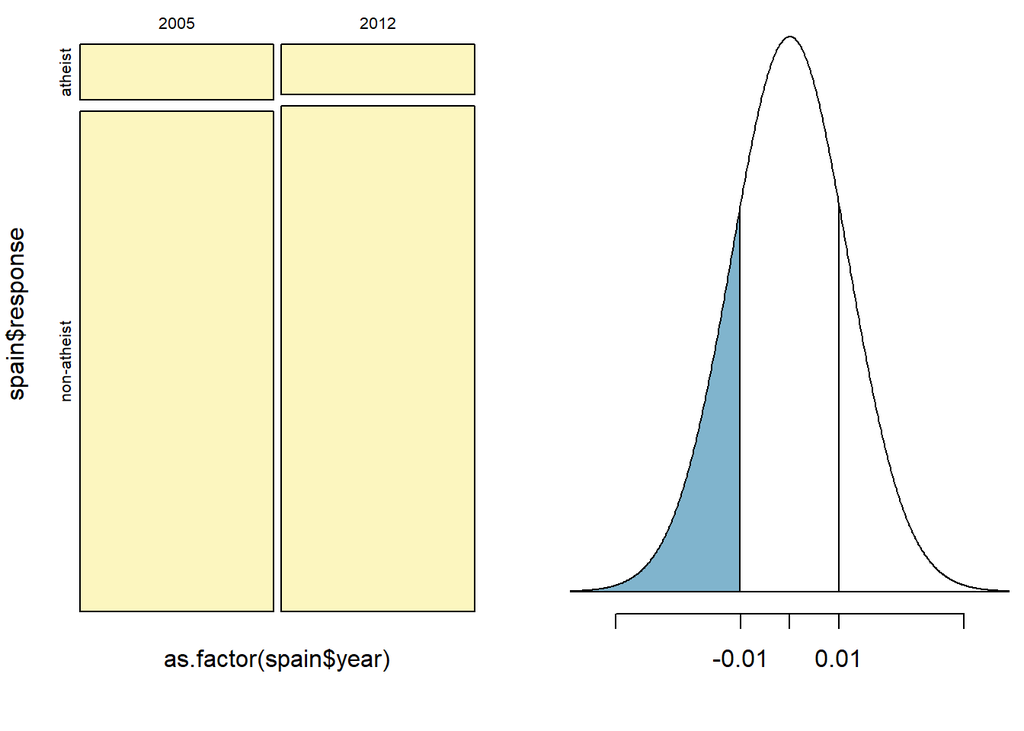

$H_0: P_{2005} - P_{2012} = 0$  
There is no difference between the proportion of atheism in Spain in 2005 and 2012.  
$H_A: P_{2005} - P_{2012} \neq 0$  
There is some difference between the proportion of atheism in Spain in 2005 and 2012.  
The observed p-value is 0.3966, larger than $\alpha(0.05)$, so we have no strong evidence to reject H0. That is to say, there is no significant difference between the proportion of atheism in Spain in 2005 and 2012.

### Ex10

Currently, the sample size of year 2005 is 1146, and that of 2012 is 1145. It doesn’t matter if the sample size changes, as long as they are not extremely small. However, we should keep in mind that as n1 and n2 changes, the degree of freedom changes, too.